# Binary Classification Model for the Parkinsons Dataset

## I. Introduction

The dataset that will be used for this project is the Parkinsons Data Set from the UCI Machine Learning Repository. The dataset consists of predictor variables (X) which are various biomedical voice measurements taken from patient audio recordings, and annotations (Y) that identify the patients as being healthy or having Parkinson’s. The predictor variables include the average vocal fundamental frequency in the recording, and measures of variation in frequency and amplitude over the course of the recording. The data was taken from a study of 31 patients, 23 of whom had Parkinson’s, with each person contributing about 6 recordings to the dataset. Each row in the .csv file corresponds to all the predictor variables associated with one recording and one column called “status” is a binary variable indicating the patient as having Parkinson’s (1) or being healthy (0). The .csv file had no empty rows or cells, and did not require additional cleaning prior to being imported. However, two rows of comments prefaced by “#” were added above the data to clarify the contents of the file.

The goal of this project will be to identify the most optimal binary classification model to predict the status of a patient (as having Parkinson’s or being healthy) based on the given predictor variables. Exploratory data analysis on the Parkinsons Data Set via graphical plots will first be conducted to determine which predictors would be appropriate for this task using and to investigate the relationships and correlations between predictors. A series of different classification models will then be investigated, starting from logistic regression containing one predictor variable to logistic regression containing multiple predictors, Naive Bayes, regularized logistic regression, boosted logistic regression, and random forests. With the “best” model determined, the model’s hyperparameters will finally be further fine-tuned to further improve classification performance.

First load in the required libraries:

```r
library(caret)
library(corrplot)
library(DataExplorer)
library(naivebayes)
library(ranger)
library(LiblineaR)
library(pROC)
set.seed(1237)
```

Use read.csv() to load in the ‘parkinsons.csv’ dataset:

```r
my.data = read.csv('../Data/parkinsons.csv',comm='#')
```

The “names” column contains the id numbers associated with each patient and is unnecessary for the subsequent analysis. Remove the column from the data frame:

```r
my.data = my.data[,-1]
summary(my.data)
```

```
##   MDVP.Fo.Hz.      MDVP.Fhi.Hz.    MDVP.Flo.Hz.    MDVP.Jitter...
##  Min.   : 88.33   Min.   :102.1   Min.   : 65.48   Min.   :0.001680
##  1st Qu.:117.57   1st Qu.:134.9   1st Qu.: 84.29   1st Qu.:0.003460
##  Median :148.79   Median :175.8   Median :104.31   Median :0.004940
##  Mean   :154.23   Mean   :197.1   Mean   :116.32   Mean   :0.006220
##  3rd Qu.:182.77   3rd Qu.:224.2   3rd Qu.:140.02   3rd Qu.:0.007365
##  Max.   :260.11   Max.   :592.0   Max.   :239.17   Max.   :0.033160
##  MDVP.Jitter.Abs.       MDVP.RAP           MDVP.PPQ
##  Min.   :7.000e-06   Min.   :0.000680   Min.   :0.000920
##  1st Qu.:2.000e-05   1st Qu.:0.001660   1st Qu.:0.001860
##  Median :3.000e-05   Median :0.002500   Median :0.002690
##  Mean   :4.396e-05   Mean   :0.003306   Mean   :0.003446
##  3rd Qu.:6.000e-05   3rd Qu.:0.003835   3rd Qu.:0.003955
##  Max.   :2.600e-04   Max.   :0.021440   Max.   :0.019580
##    Jitter.DDP        MDVP.Shimmer     MDVP.Shimmer.dB.  Shimmer.APQ3
##  Min.   :0.002040   Min.   :0.00954   Min.   :0.0850   Min.   :0.004550
##  1st Qu.:0.004985   1st Qu.:0.01650   1st Qu.:0.1485   1st Qu.:0.008245
##  Median :0.007490   Median :0.02297   Median :0.2210   Median :0.012790
##  Mean   :0.009920   Mean   :0.02971   Mean   :0.2823   Mean   :0.015664
##  3rd Qu.:0.011505   3rd Qu.:0.03789   3rd Qu.:0.3500   3rd Qu.:0.020265
##  Max.   :0.064330   Max.   :0.11908   Max.   :1.3020   Max.   :0.056470
##   Shimmer.APQ5        MDVP.APQ        Shimmer.DDA           NHR
##  Min.   :0.00570   Min.   :0.00719   Min.   :0.01364   Min.   :0.000650
##  1st Qu.:0.00958   1st Qu.:0.01308   1st Qu.:0.02474   1st Qu.:0.005925
##  Median :0.01347   Median :0.01826   Median :0.03836   Median :0.011660
##  Mean   :0.01788   Mean   :0.02408   Mean   :0.04699   Mean   :0.024847
##  3rd Qu.:0.02238   3rd Qu.:0.02940   3rd Qu.:0.06080   3rd Qu.:0.025640
##  Max.   :0.07940   Max.   :0.13778   Max.   :0.16942   Max.   :0.314820
##       HNR             status            RPDE             DFA
##  Min.   : 8.441   Min.   :0.0000   Min.   :0.2566   Min.   :0.5743
##  1st Qu.:19.198   1st Qu.:1.0000   1st Qu.:0.4213   1st Qu.:0.6748
##  Median :22.085   Median :1.0000   Median :0.4960   Median :0.7223
##  Mean   :21.886   Mean   :0.7538   Mean   :0.4985   Mean   :0.7181
##  3rd Qu.:25.076   3rd Qu.:1.0000   3rd Qu.:0.5876   3rd Qu.:0.7619
##  Max.   :33.047   Max.   :1.0000   Max.   :0.6852   Max.   :0.8253
##     spread1          spread2               D2             PPE
##  Min.   :-7.965   Min.   :0.006274   Min.   :1.423   Min.   :0.04454
##  1st Qu.:-6.450   1st Qu.:0.174350   1st Qu.:2.099   1st Qu.:0.13745
##  Median :-5.721   Median :0.218885   Median :2.362   Median :0.19405
##  Mean   :-5.684   Mean   :0.226510   Mean   :2.382   Mean   :0.20655
##  3rd Qu.:-5.046   3rd Qu.:0.279234   3rd Qu.:2.636   3rd Qu.:0.25298
##  Max.   :-2.434   Max.   :0.450493   Max.   :3.671   Max.   :0.52737
```

The “status” column is a binary indicator variable that is interpreted by the data frame as quantiative. Ensure that it is a numeric vector by using as.numeric():

```r
my.data$status = as.numeric(my.data$status)
names(my.data)
```

```
##  [1] "MDVP.Fo.Hz."      "MDVP.Fhi.Hz."     "MDVP.Flo.Hz."
##  [4] "MDVP.Jitter..."   "MDVP.Jitter.Abs." "MDVP.RAP"
##  [7] "MDVP.PPQ"         "Jitter.DDP"       "MDVP.Shimmer"
## [10] "MDVP.Shimmer.dB." "Shimmer.APQ3"     "Shimmer.APQ5"
## [13] "MDVP.APQ"         "Shimmer.DDA"      "NHR"
## [16] "HNR"              "status"           "RPDE"
## [19] "DFA"              "spread1"          "spread2"
## [22] "D2"               "PPE"
```

## II. Exploratory Data Analysis

The first visualization I will use to perform exploratory data analysis is a correlation matrix. Concretely “corrplot” from the corrplot package will be used to graphically depict the matrix of correlation coefficients between each combination of predictor variables.

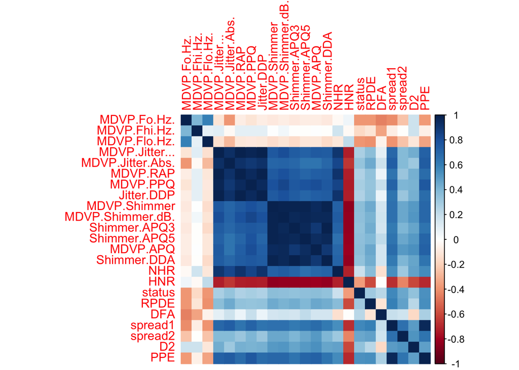

```r
corrplot(cor(my.data),method='color')
```

```r
cor(my.data)
```

```
##                  MDVP.Fo.Hz. MDVP.Fhi.Hz. MDVP.Flo.Hz. MDVP.Jitter...
## MDVP.Fo.Hz.       1.00000000  0.400984676   0.59654552    -0.11800263
## MDVP.Fhi.Hz.      0.40098468  1.000000000   0.08495125     0.10208635
## MDVP.Flo.Hz.      0.59654552  0.084951251   1.00000000    -0.13991889
## MDVP.Jitter...   -0.11800263  0.102086349  -0.13991889     1.00000000
## MDVP.Jitter.Abs. -0.38202665 -0.029198333  -0.27781524     0.93571398
## MDVP.RAP         -0.07619381  0.097176619  -0.10051932     0.99027559
## MDVP.PPQ         -0.11216543  0.091126194  -0.09582837     0.97425639
## Jitter.DDP       -0.07621269  0.097149867  -0.10048768     0.99027622
## MDVP.Shimmer     -0.09837375  0.002281231  -0.14454332     0.76906323
## MDVP.Shimmer.dB. -0.07374246  0.043465164  -0.11908865     0.80428928
## Shimmer.APQ3     -0.09471706 -0.003743251  -0.15074650     0.74662520
## Shimmer.APQ5     -0.07068178 -0.009996776  -0.10109462     0.72556100
## MDVP.APQ         -0.07777382  0.004936985  -0.10729342     0.75825526
## Shimmer.DDA      -0.09473157 -0.003732893  -0.15073674     0.74663517
## NHR              -0.02198078  0.163766404  -0.10867045     0.90695860
## HNR               0.05914439 -0.024893140   0.21085090    -0.72816507
## status           -0.38353515 -0.166136347  -0.38020043     0.27821960
## RPDE             -0.38389390 -0.112403513  -0.40014307     0.36067348
## DFA              -0.44601329 -0.343096724  -0.05040631     0.09857244
## spread1          -0.41373817 -0.076657801  -0.39485736     0.69357671
## spread2          -0.24945005 -0.002953614  -0.24382940     0.38512347
## D2                0.17797951  0.176322818  -0.10062909     0.43343402
## PPE              -0.37235638 -0.069543002  -0.34007134     0.72154293
##                  MDVP.Jitter.Abs.    MDVP.RAP    MDVP.PPQ  Jitter.DDP
## MDVP.Fo.Hz.           -0.38202665 -0.07619381 -0.11216543 -0.07621269
## MDVP.Fhi.Hz.          -0.02919833  0.09717662  0.09112619  0.09714987
## MDVP.Flo.Hz.          -0.27781524 -0.10051932 -0.09582837 -0.10048768
## MDVP.Jitter...         0.93571398  0.99027559  0.97425639  0.99027622
## MDVP.Jitter.Abs.       1.00000000  0.92291097  0.89777790  0.92291303
## MDVP.RAP               0.92291097  1.00000000  0.95731689  0.99999960
## MDVP.PPQ               0.89777790  0.95731689  1.00000000  0.95731916
## Jitter.DDP             0.92291303  0.99999960  0.95731916  1.00000000
## MDVP.Shimmer           0.70332237  0.75958052  0.79782603  0.75955470
## MDVP.Shimmer.dB.       0.71660128  0.79065155  0.83923894  0.79062060
## Shimmer.APQ3           0.69715303  0.74491236  0.76357992  0.74489376
## Shimmer.APQ5           0.64896070  0.70992682  0.78678047  0.70990709
## MDVP.APQ               0.64879344  0.73745467  0.80413930  0.73743867
## Shimmer.DDA            0.69716971  0.74491923  0.76359216  0.74490062
## NHR                    0.83497218  0.91952071  0.84460353  0.91954818
```

[output cut: 89 more lines]

```
## MDVP.Shimmer      0.452024826  0.5070883  0.6937707
## MDVP.Shimmer.dB.  0.454314373  0.5122332  0.6950581
## Shimmer.APQ3      0.402242954  0.4672654  0.6453767
## Shimmer.APQ5      0.457194945  0.5021744  0.7024557
## MDVP.APQ          0.502187886  0.5368690  0.7216940
## Shimmer.DDA       0.402223092  0.4672614  0.6453890
## NHR               0.318098962  0.4709488  0.5525913
## HNR              -0.431563748 -0.6014010 -0.6928759
## status            0.454842126  0.3402315  0.5310392
## RPDE              0.479904528  0.2369314  0.5458857
## DFA               0.166548111 -0.1653810  0.2704447
## spread1           0.652357812  0.4951227  0.9624353
## spread2           1.000000000  0.5235317  0.6447110
## D2                0.523531735  1.0000000  0.4805845
## PPE               0.644710959  0.4805845  1.0000000
```

The second visualization I will use is plots of the distribution of each predictor variable. Kernel density plots will be used instead of histograms, the results of which depend on the number of bins used:

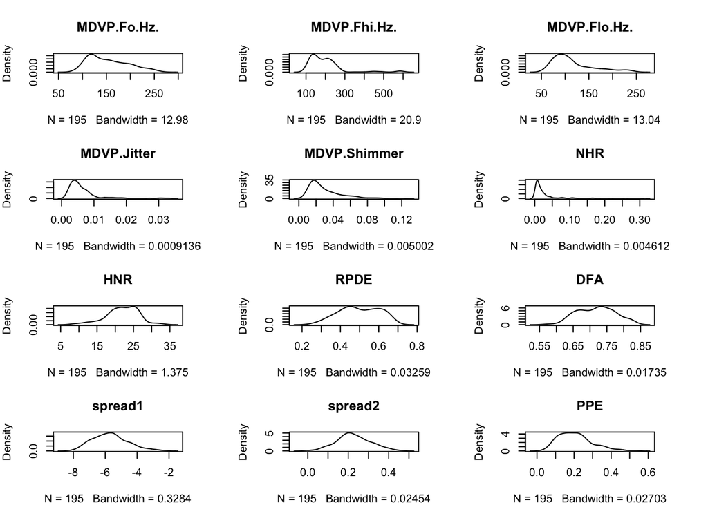

```r
op = par(mfrow=c(4,3),mar=c(4,4,4,4))
plot(density(my.data$MDVP.Fo.Hz.),main="MDVP.Fo.Hz.")
plot(density(my.data$MDVP.Fhi.Hz.),main="MDVP.Fhi.Hz.")
plot(density(my.data$MDVP.Flo.Hz.),main="MDVP.Flo.Hz.")
plot(density(my.data$MDVP.Jitter...),main="MDVP.Jitter")
plot(density(my.data$MDVP.Shimmer),main="MDVP.Shimmer")
plot(density(my.data$NHR),main="NHR")
plot(density(my.data$HNR),main="HNR")
plot(density(my.data$RPDE),main="RPDE")
plot(density(my.data$DFA),main="DFA")
plot(density(my.data$spread1),main="spread1")
plot(density(my.data$spread2),main="spread2")
plot(density(my.data$PPE),main="PPE")
```

```r
par(op)
```

It appears that most of the predictor variables have distributions that lie close to the ideal shape of a normal distribution with the exception of “MDVP.Jitter…,” “NHR,” and “MDVP.Shimmer,” which are right skewed. These variables could be transformed to more closely resemble normal distributions but, for the purpose of this analysis, the deviation from ideal will not be assumed significant enough to warrant correction.

It is also useful to plot the distributions of the predictor variables by the binary response variable “status” in order to see how the distributions of values differ for each of the output classes. Use “plot_boxplot” from the DataExplorer package to achieve these kinds of distributions. Note for the “plot_boxplot” method that the response variable should be converted to a factor with two levels (1 and 0) for better visualization:

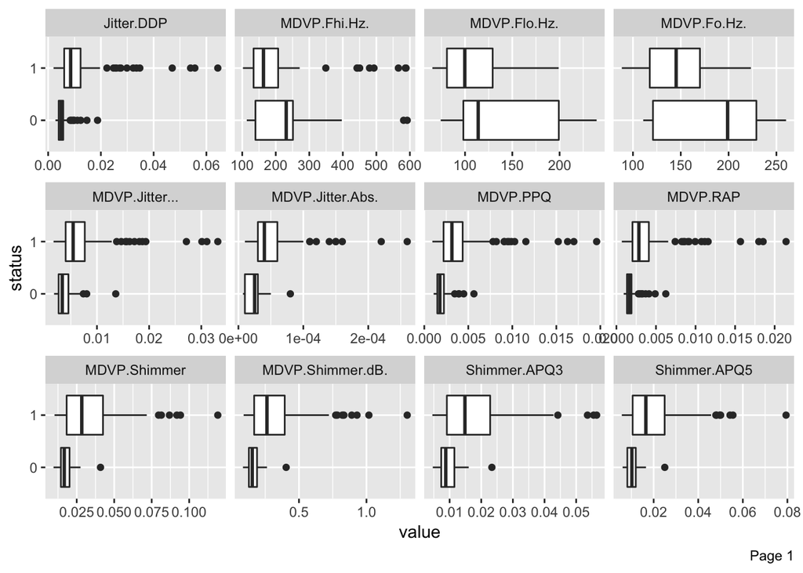

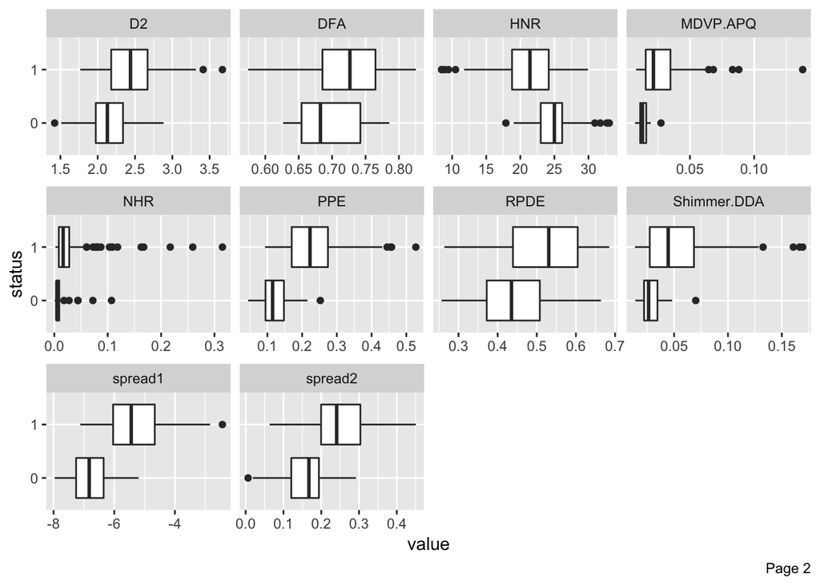

```r
my.data$status = factor(my.data$status)
plot_boxplot(my.data,"status")
```

For many variables like spread1 and PPE, it appears that the distributions of values (median, interquartile range, etc.) are different for class “status”==0 (indicating patient is healthy) and class “status”==1 (indicating patient has Parkinson’s), i.e. different ranges of values of the predictors correspond to the different classes. Therefore, using these variables as predictors would facilitate making classification decisions.

createDataPartition() will now be used to split the dataset into a training set (used to train the model) and test set (used to evaluate the model’s ability to generalize on unseen data), such that 75% of the dataset lies in the training set. For subsequent analysis, the response variable “status” must be numeric.

```r
my.data$status = as.numeric(as.character(my.data$status))
indices = createDataPartition(y=my.data$status,p=0.75,list=FALSE)
training.set = my.data[indices,]
test.set = my.data[-indices,]
nrow(training.set)
```

```
## [1] 147
```

```r
nrow(test.set)
```

```
## [1] 48
```

## III. Logistic Regression (One Predictor)

The first model I will investigate is logistic regression, as covered in the Essential R notes and created solely using functions from base R. I will create a binary classification model using only one predictor (spread1) in order to examine how useful a simpler model would be (and see if a more complex model with multiple predictors is necessary).

First I will plot “status” as a function of “spread1,” using the jitter function to help visualize the points:

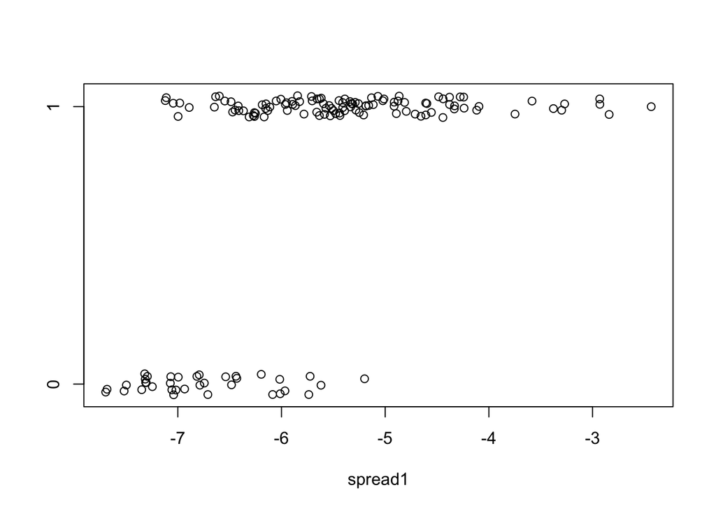

```r
with(training.set, plot(spread1,jitter(status,amount=0.04),
                        ylab="",yaxt="n"))
axis(side=2, at=0:1, labels=c("0","1"))
```

Fit a logistic regression model using glm() on the training set:

```r
lr1 = glm(status~spread1, family="binomial", data=training.set)
summary(lr1)
```

```
##
## Call:
## glm(formula = status ~ spread1, family = "binomial", data = training.set)
##
## Deviance Residuals:
##      Min        1Q    Median        3Q       Max
## -2.59800   0.01388   0.23979   0.52057   1.68108
##
## Coefficients:
##             Estimate Std. Error z value Pr(>|z|)
## (Intercept)  15.4416     2.6481   5.831  5.5e-09 ***
## spread1       2.3277     0.4128   5.640  1.7e-08 ***
## ---
## Signif. codes:  0 '***' 0.001 '**' 0.01 '*' 0.05 '.' 0.1 ' ' 1
##
## (Dispersion parameter for binomial family taken to be 1)
##
##     Null deviance: 163.658  on 146  degrees of freedom
## Residual deviance:  99.256  on 145  degrees of freedom
## AIC: 103.26
##
## Number of Fisher Scoring iterations: 6
```

Plot the logistic regression model to examine the fit:

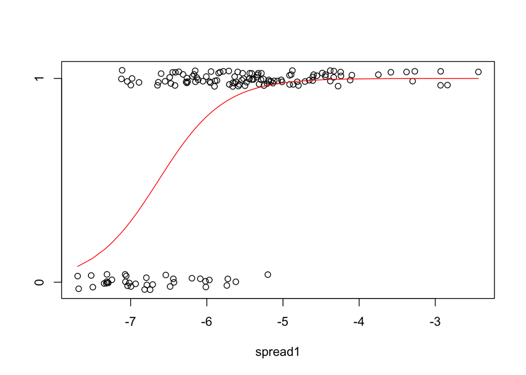

```r
with(training.set, plot(spread1,jitter(status,amount=0.04),
                        ylab="",yaxt="n"))
axis(side=2, at=0:1, labels=c("0","1"))
lines(cbind(training.set$spread1,lr1$fitted)
           [order(training.set$spread1),], col="red")
```

Plot the residual plots:

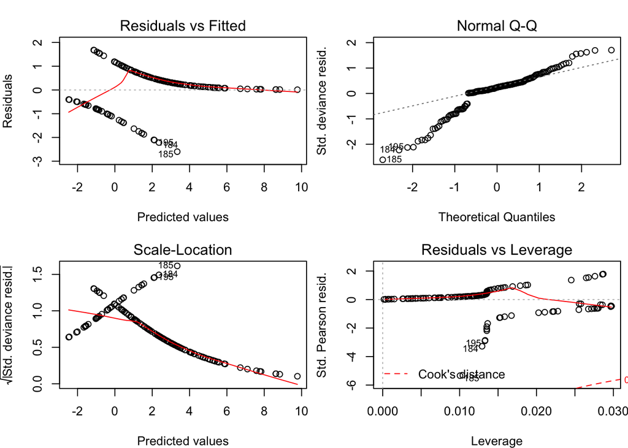

```r
op = par(mfrow=c(2,2),mar=c(4,4,2.5,0.5))
plot(lr1)
```

```r
par(op)
```

There appears to be a pattern in the residuals vs fits plot, since “status” can only take a value of 0 or 1, and the model cannot predict intermediate values.

Evaluate the model’s overall performance by computing the p-value of a chi-squared statistic comparing the null and residual deviance:

```r
with(lr1, pchisq(null.deviance - deviance, df.null - df.residual,
                 lower.tail=FALSE))
```

```
## [1] 1.014322e-15
```

The p-value of is close to 0, indicating the model explains a significant amount of deviance.

Use the roc() function from the pROC package to plot a ROC curve, a useful plot for binary classification problems that typically plots the true positive rate vs the false positive rate at different threshold settings, where the “threshold” is a variable boundary between the classes of interest. The “AUC” score, computed by auc() is a single number performance metric used to summarize the results displayed in a ROC curve (with higher values indicating better performance):

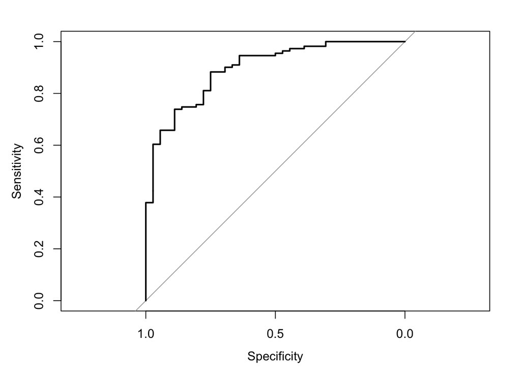

```r
roc.curve = roc(training.set$status,lr1$fitted)
plot(roc.curve)
```

```r
auc(roc.curve)
```

```
## Area under the curve: 0.8949
```

## IV. Logistic Regression (Multiple Predictors)

I will now use the caret package to analyze a series of different binary classification models (all now containing multiple predictors), with the goal of determining the most optimal one for this particular problem. The “caret” package is chosen for its streamlined interface, which enables quick prototyping and tuning of parameters for different models. For the subsequent analysis, the “status” variable must be converted to a factor and the names of the levels changed to “Zero” and “One” instead of “0” and “1,” respectively, in order to conform to standards for variable naming in R:

```r
training.set$status = factor(training.set$status)
levels(training.set$status) = c("Zero","One")
test.set$status = factor(test.set$status)
levels(test.set$status) = c("Zero","One")
```

The primary function in caret is train() which trains a specified (binary classification) model on the dataset. A helper function called trainControl() is used to modify how train() operates on the dataset, i.e. it determines what hyperparameters are used to set up the model and how those hyperparameters are evaluated to determine the most optimal combination. (Hyperparameters are parameters not calculated during training, but must instead be pre-set by the user and optimized through experimentation. In support vector machines, for example, the cost parameter C is a hyperparameter used to determine how large coefficients in the model can be. Each classification model has a different set of hyperparameters that require tuning).

```r
trControl = trainControl(method = "repeatedcv",
                         number = 5,
                         repeats = 3,
                         classProbs = TRUE,
                         summaryFunction = defaultSummary)
```

In the arguments to trainControl(), I specified that repeated k-fold cross-validation (with 5 folds and 3 repeats) will be used to evaluate the optimal set of hyperparameters. Repeated cross validation involves splitting the training set into k folds or partitions, and the following procedure conducted for each fold: after creating the model with the desired combination of hyperparameters, (k-1) folds are used for training and the remaining unseen fold is used for testing or “validation”. A “defaultSummary” will be used to display the performance metrics of the model and the argument “classProbs” was set to TRUE so that class probabilities (instead of final class decisions) are output by the model. (Class probabilities are necessary for the construction of ROC curves and computation of AUC scores). Lastly, for the purpose of simplicity, the default tuning grid of hyperparameters used by trainControl() and train() will be used. In the final analysis, a custom tuning grid will be created to further fine-tune the hyperparameter selection.

The train() function will now be used to fit a logistic regression model on all predictor variables in the dataset (instead of only the predictor “spread1” as described previously) using the metric “Accuracy” to select the best set of hyperparameters.

```r
model = train(form=status~.,data=training.set, method="glm",
              family="binomial", metric="Accuracy",
              trControl=trControl)
summary(model)
```

```
##
## Call:
## NULL
##
## Deviance Residuals:
##      Min        1Q    Median        3Q       Max
## -2.43151   0.00000   0.03345   0.27893   1.92431
##
## Coefficients:
##                    Estimate Std. Error z value Pr(>|z|)
## (Intercept)      -3.897e+01  2.286e+01  -1.705   0.0883 .
## MDVP.Fo.Hz.      -2.576e-02  3.370e-02  -0.764   0.4447
## MDVP.Fhi.Hz.     -1.827e-03  6.639e-03  -0.275   0.7832
## MDVP.Flo.Hz.      1.581e-02  1.731e-02   0.913   0.3612
## MDVP.Jitter...   -8.849e+02  1.415e+03  -0.626   0.5316
## MDVP.Jitter.Abs. -8.522e+04  1.317e+05  -0.647   0.5177
## MDVP.RAP         -1.860e+05  1.937e+05  -0.960   0.3369
## MDVP.PPQ         -4.518e+03  2.646e+03  -1.707   0.0877 .
## Jitter.DDP        6.393e+04  6.478e+04   0.987   0.3237
## MDVP.Shimmer      7.443e+02  1.189e+03   0.626   0.5313
## MDVP.Shimmer.dB.  2.211e+01  3.954e+01   0.559   0.5761
## Shimmer.APQ3     -6.951e+04  1.553e+05  -0.448   0.6544
## Shimmer.APQ5     -2.214e+02  5.192e+02  -0.426   0.6698
## MDVP.APQ          2.996e+02  4.711e+02   0.636   0.5248
## Shimmer.DDA       2.266e+04  5.175e+04   0.438   0.6615
## NHR               4.268e+01  5.573e+01   0.766   0.4438
## HNR               2.533e-01  2.599e-01   0.975   0.3298
## RPDE              6.620e-01  5.849e+00   0.113   0.9099
## DFA               9.587e+00  1.187e+01   0.807   0.4194
## spread1          -1.742e+00  2.178e+00  -0.800   0.4238
## spread2           1.656e+01  8.585e+00   1.929   0.0537 .
## D2                1.416e+00  1.771e+00   0.799   0.4240
## PPE               7.047e+01  3.686e+01   1.912   0.0559 .
## ---
## Signif. codes:  0 '***' 0.001 '**' 0.01 '*' 0.05 '.' 0.1 ' ' 1
##
## (Dispersion parameter for binomial family taken to be 1)
##
##     Null deviance: 163.658  on 146  degrees of freedom
## Residual deviance:  59.303  on 124  degrees of freedom
## AIC: 105.3
##
## Number of Fisher Scoring iterations: 9
```

predict() will be used to make predictions from the model on the test set:

```r
pred = predict(object=model,newdata=test.set)
```

table() can be used to display how many predictions of “Zero” vs “One” were made by the model:

```r
table(pred)
```

```
## pred
## Zero  One
##   12   36
```

The confusionMatrix() function can be used to output important information regarding the performance of the model on the test set, such as the sensitivity, specificity, and accuracy. The function also displays a confusion matrix of the true positive rate, true negative rate, false positive rate, and false negative rate.

```r
conf.matrix = confusionMatrix(data=pred,reference=test.set[,'status'])
conf.matrix
```

```
## Confusion Matrix and Statistics
##
##           Reference
## Prediction Zero One
##       Zero    8   4
##       One     4  32
##
##                Accuracy : 0.8333
##                  95% CI : (0.6978, 0.9252)
##     No Information Rate : 0.75
##     P-Value [Acc > NIR] : 0.119
##
##                   Kappa : 0.5556
##  Mcnemar's Test P-Value : 1.000
##
##             Sensitivity : 0.6667
##             Specificity : 0.8889
##          Pos Pred Value : 0.6667
##          Neg Pred Value : 0.8889
##              Prevalence : 0.2500
##          Detection Rate : 0.1667
##    Detection Prevalence : 0.2500
##       Balanced Accuracy : 0.7778
##
##        'Positive' Class : Zero
##
```

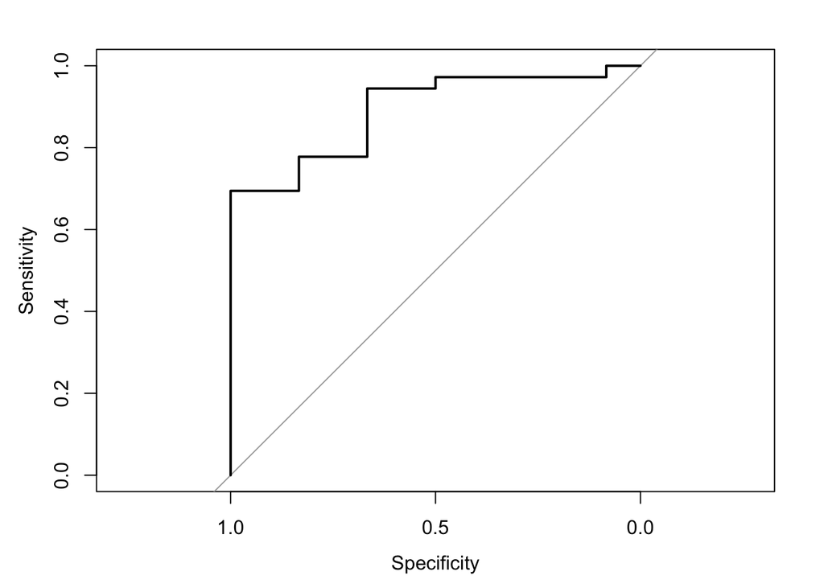

```r
pred = predict(object=model,newdata=test.set,type="prob")
roc.curve = roc(test.set$status=="One",pred$One)
plot(roc.curve)
```

```r
auc(roc.curve)
```

```
## Area under the curve: 0.8912
```

## V. Naive Bayes

A Naive Bayes model will now be fit on the dataset. “Naive Bayes” is a probabilistic classification model that relies upon the assumption that all features are independent.

```r
model = train(form=status~.,data=training.set, method="naive_bayes",
              metric="Accuracy", trControl = trControl)
summary(model)
```

```
##             Length Class      Mode
## data         2     -none-     list
## levels       2     -none-     character
## laplace      1     -none-     numeric
## tables      22     -none-     list
## prior        2     table      numeric
## usekernel    1     -none-     logical
## call         6     -none-     call
## xNames      22     -none-     character
## problemType  1     -none-     character
## tuneValue    3     data.frame list
## obsLevels    2     -none-     character
## param        0     -none-     list
```

```r
pred = predict(object=model,newdata=test.set)
table(pred)
```

```
## pred
## Zero  One
##   23   25
```

```r
conf.matrix = confusionMatrix(data=pred,reference=test.set[,'status'])
conf.matrix
```

```
## Confusion Matrix and Statistics
##
##           Reference
## Prediction Zero One
##       Zero   12  11
##       One     0  25
##
##                Accuracy : 0.7708
##                  95% CI : (0.6269, 0.8797)
##     No Information Rate : 0.75
##     P-Value [Acc > NIR] : 0.444771
##
##                   Kappa : 0.5319
##  Mcnemar's Test P-Value : 0.002569
##
##             Sensitivity : 1.0000
##             Specificity : 0.6944
##          Pos Pred Value : 0.5217
##          Neg Pred Value : 1.0000
##              Prevalence : 0.2500
##          Detection Rate : 0.2500
##    Detection Prevalence : 0.4792
##       Balanced Accuracy : 0.8472
##
##        'Positive' Class : Zero
##
```

This model achieves higher sensitivity, lower specificity, and lower accuracy compared to the logistic regression model and will therefore not be considered further.

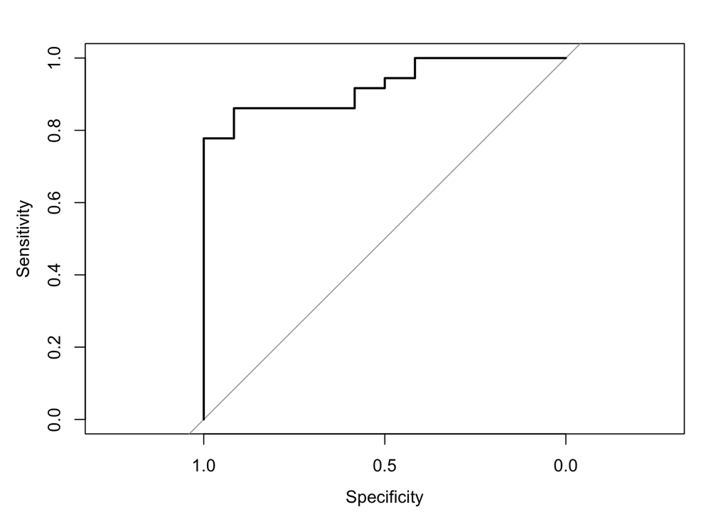

```r
pred = predict(object=model,newdata=test.set,type="prob")
roc.curve = roc(test.set$status=="One",pred$One)
plot(roc.curve)
```

```r
auc(roc.curve)
```

```
## Area under the curve: 0.9236
```

## VI. Regularized Logistic Regression

A regularized logistic regression model will now be investigated. This model adds a penalty term to constrain the magnitude of the coefficients, thereby reducing the model’s variance (letting the coefficient estimates be more stable).

```r
model = train(form=status~.,data=training.set, method="regLogistic",
              metric="Accuracy", trControl = trControl)
summary(model)
```

```
##             Length Class      Mode
## TypeDetail   1     -none-     character
## Type         1     -none-     numeric
## W           23     -none-     numeric
## Bias         1     -none-     numeric
## ClassNames   2     factor     numeric
## NbClass      1     -none-     numeric
## xNames      22     -none-     character
## problemType  1     -none-     character
## tuneValue    3     data.frame list
## obsLevels    2     -none-     character
## param        0     -none-     list
```

```r
pred = predict(object=model,newdata=test.set)
table(pred)
```

```
## pred
## Zero  One
##    4   44
```

```r
conf.matrix = confusionMatrix(data=pred,reference=test.set[,'status'])
conf.matrix
```

```
## Confusion Matrix and Statistics
##
##           Reference
## Prediction Zero One
##       Zero    4   0
##       One     8  36
##
##                Accuracy : 0.8333
##                  95% CI : (0.6978, 0.9252)
##     No Information Rate : 0.75
##     P-Value [Acc > NIR] : 0.11905
##
##                   Kappa : 0.4286
##  Mcnemar's Test P-Value : 0.01333
##
##             Sensitivity : 0.33333
##             Specificity : 1.00000
##          Pos Pred Value : 1.00000
##          Neg Pred Value : 0.81818
##              Prevalence : 0.25000
##          Detection Rate : 0.08333
##    Detection Prevalence : 0.08333
##       Balanced Accuracy : 0.66667
##
##        'Positive' Class : Zero
##
```

This model achieves much lower sensitivity compared to the original logistic regression model, and will not be a candidate for further investigation.

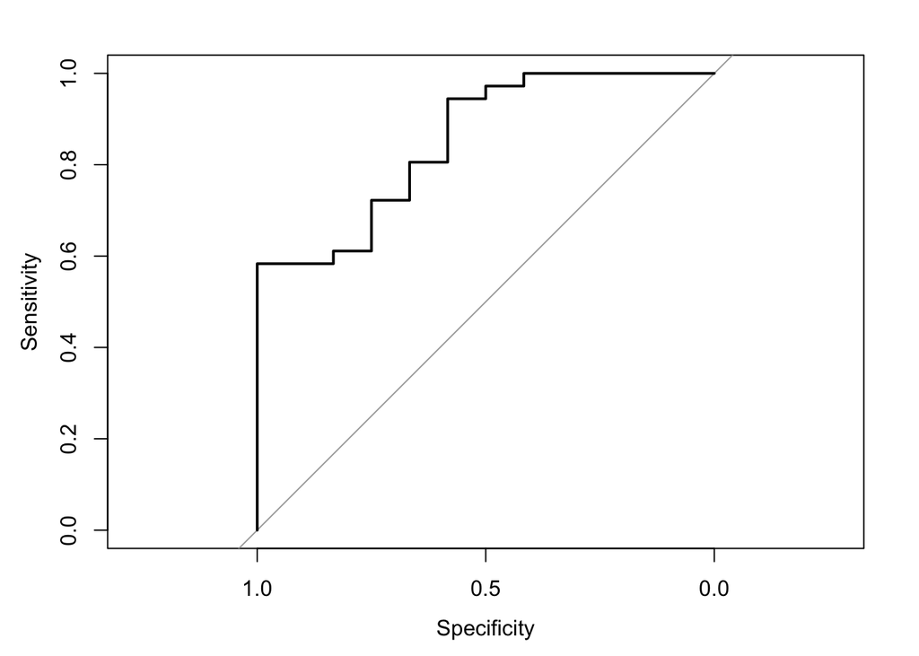

```r
pred = predict(object=model,newdata=test.set,type="prob")
roc.curve = roc(test.set$status=="One",pred$One)
plot(roc.curve)
```

```r
auc(roc.curve)
```

```
## Area under the curve: 0.8519
```

## VII. Boosted Logistic Regression

A boosted logistic regression model will now be investigated. This model uses a technique called “boosting,” whereby an ensemble of weak learners is trained sequentially, thereby decreasing bias and more heavily weighting misclassified examples from previous base learners.Instead of the classical exponential loss used in the “Adaboost” algorithm, boosted logistic regression implements the log-loss as used in logistic regression.

```r
model = train(form=status~.,data=training.set, method="LogitBoost",
              metric="Accuracy", trControl = trControl)
summary(model)
```

```
##             Length Class      Mode
## Stump       93     -none-     numeric
## lablist      2     factor     numeric
## xNames      22     -none-     character
## problemType  1     -none-     character
## tuneValue    1     data.frame list
## obsLevels    2     -none-     character
## param        0     -none-     list
```

```r
pred = predict(object=model,newdata=test.set)
table(pred)
```

```
## pred
## Zero  One
##   11   37
```

```r
conf.matrix = confusionMatrix(data=pred,reference=test.set[,'status'])
conf.matrix
```

```
## Confusion Matrix and Statistics
##
##           Reference
## Prediction Zero One
##       Zero    9   2
##       One     3  34
##
##                Accuracy : 0.8958
##                  95% CI : (0.7734, 0.9653)
##     No Information Rate : 0.75
##     P-Value [Acc > NIR] : 0.0103
##
##                   Kappa : 0.7143
##  Mcnemar's Test P-Value : 1.0000
##
##             Sensitivity : 0.7500
##             Specificity : 0.9444
##          Pos Pred Value : 0.8182
##          Neg Pred Value : 0.9189
##              Prevalence : 0.2500
##          Detection Rate : 0.1875
##    Detection Prevalence : 0.2292
##       Balanced Accuracy : 0.8472
##
##        'Positive' Class : Zero
##
```

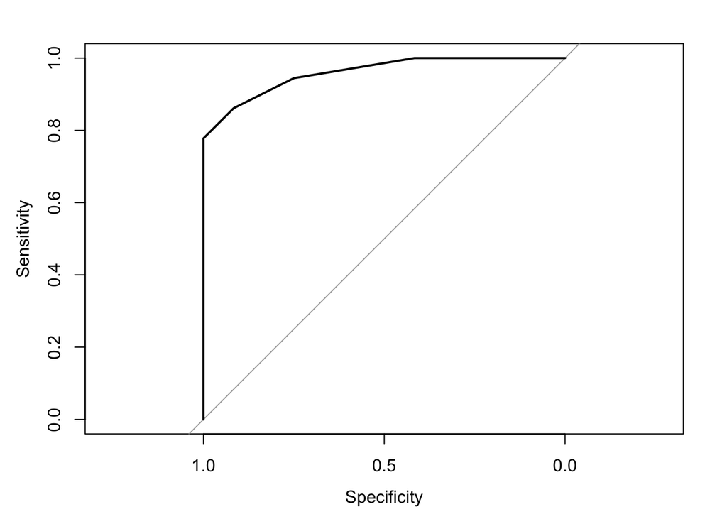

```r
pred = predict(object=model,newdata=test.set,type="prob")
roc.curve = roc(test.set$status=="One",pred$One)
plot(roc.curve)
```

```r
auc(roc.curve)
```

```
## Area under the curve: 0.9595
```

## VIII. Random Forest

The last model of interest is a random forest model, constructed by creating an ensemble of decision trees where the final prediction is a weighted average or majority vote of the ensemble’s predictions, thereby reducing the variance problem faced by single decision trees.

```r
model = train(form=status~.,data=training.set, method="ranger",
              metric="Accuracy", trControl = trControl)
summary(model)
```

```
##                           Length Class         Mode
## predictions               294    -none-        numeric
## num.trees                   1    -none-        numeric
## num.independent.variables   1    -none-        numeric
## mtry                        1    -none-        numeric
## min.node.size               1    -none-        numeric
## prediction.error            1    -none-        numeric
## forest                     11    ranger.forest list
## splitrule                   1    -none-        character
## treetype                    1    -none-        character
## call                        9    -none-        call
## importance.mode             1    -none-        character
## num.samples                 1    -none-        numeric
## replace                     1    -none-        logical
## xNames                     22    -none-        character
## problemType                 1    -none-        character
## tuneValue                   3    data.frame    list
## obsLevels                   2    -none-        character
## param                       0    -none-        list
```

```r
pred = predict(object=model,newdata=test.set)
table(pred)
```

```
## pred
## Zero  One
##   10   38
```

```r
conf.matrix = confusionMatrix(data=pred,reference=test.set[,'status'])
conf.matrix
```

```
## Confusion Matrix and Statistics
##
##           Reference
## Prediction Zero One
##       Zero    9   1
##       One     3  35
##
##                Accuracy : 0.9167
##                  95% CI : (0.8002, 0.9768)
##     No Information Rate : 0.75
##     P-Value [Acc > NIR] : 0.003207
##
##                   Kappa : 0.7647
##  Mcnemar's Test P-Value : 0.617075
##
##             Sensitivity : 0.7500
##             Specificity : 0.9722
##          Pos Pred Value : 0.9000
##          Neg Pred Value : 0.9211
##              Prevalence : 0.2500
##          Detection Rate : 0.1875
##    Detection Prevalence : 0.2083
##       Balanced Accuracy : 0.8611
##
##        'Positive' Class : Zero
##
```

This model achieved a higher accuracy and specificity compared to the previous “best” model (the boosted logistic regression model). The random forest model will therefore be investigated further with a custom tuning grid.

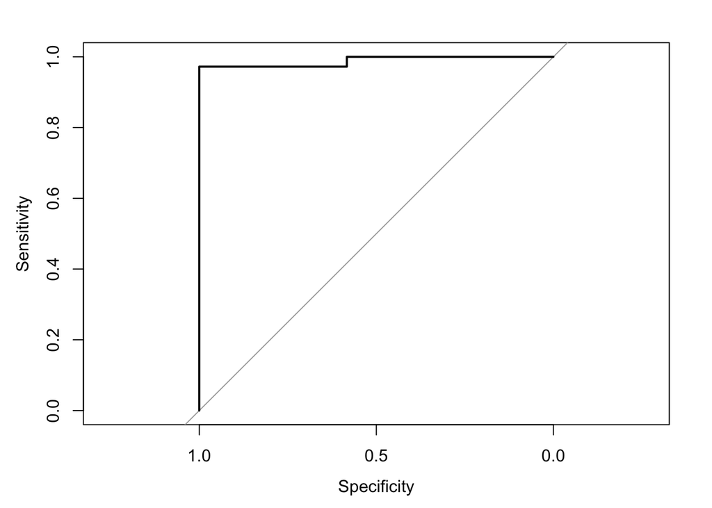

```r
pred = predict(object=model,newdata=test.set,type="prob")
roc.curve = roc(test.set$status=="One",pred$One)
plot(roc.curve)
```

```r
auc(roc.curve)
```

```
## Area under the curve: 0.9884
```

## IX. Tuning Hyperparameters of Random Forest

```r
tuneGrid = expand.grid(mtry = c(2:22),
                       splitrule = c("extratrees"),
                       min.node.size = c(1, 5, 10))
tuneGrid
```

| mtry | splitrule | min.node.size |
| --- | --- | --- |
| 2 | extratrees | 1 |
| 3 | extratrees | 1 |
| 4 | extratrees | 1 |
| 5 | extratrees | 1 |
| 6 | extratrees | 1 |
| 7 | extratrees | 1 |
| 8 | extratrees | 1 |
| 9 | extratrees | 1 |
| 10 | extratrees | 1 |
| 11 | extratrees | 1 |

[output cut: 53 more lines]

Use train() with the new tuneGrid to determine the best combination of hyperparameters using the metric “Accuracy.”

```r
train.by.grid = train(form=status~.,data=training.set,method='ranger',
                      metric = "Accuracy", tuneGrid=tuneGrid,
                      trControl=trControl)
train.by.grid['results']
```

```
## $results
##    mtry  splitrule min.node.size  Accuracy     Kappa AccuracySD   KappaSD
## 1     2 extratrees             1 0.8938351 0.6675598 0.05426105 0.2043786
## 2     2 extratrees             5 0.8801953 0.6197718 0.05109220 0.1877095
## 3     2 extratrees            10 0.8618811 0.5547113 0.05247804 0.1862689
## 4     3 extratrees             1 0.9005067 0.6908426 0.04956537 0.1872675
## 5     3 extratrees             5 0.8824941 0.6307475 0.05422291 0.1990498
## 6     3 extratrees            10 0.8732987 0.5921194 0.05072013 0.1849964
## 7     4 extratrees             1 0.8937634 0.6661205 0.04493090 0.1760501
## 8     4 extratrees             5 0.8892424 0.6566978 0.04934786 0.1795181
## 9     4 extratrees            10 0.8733754 0.5969924 0.05358932 0.1862141
## 10    5 extratrees             1 0.8960623 0.6878439 0.04368661 0.1446514
## 11    5 extratrees             5 0.8869435 0.6493873 0.04624655 0.1708829
## 12    5 extratrees            10 0.8665554 0.5816940 0.04886199 0.1732605
## 13    6 extratrees             1 0.9030355 0.7069142 0.04772365 0.1561074
```

[output cut: 50 more lines]

Print the optimal combination of hyperparameters:

```r
train.by.grid['bestTune']
```

```
## $bestTune
##    mtry  splitrule min.node.size
## 16    7 extratrees             1
```

plot() can be used on the fitted model train.by.grid to graphically display the value of accuracy corresponding to each hyperparameter combination:

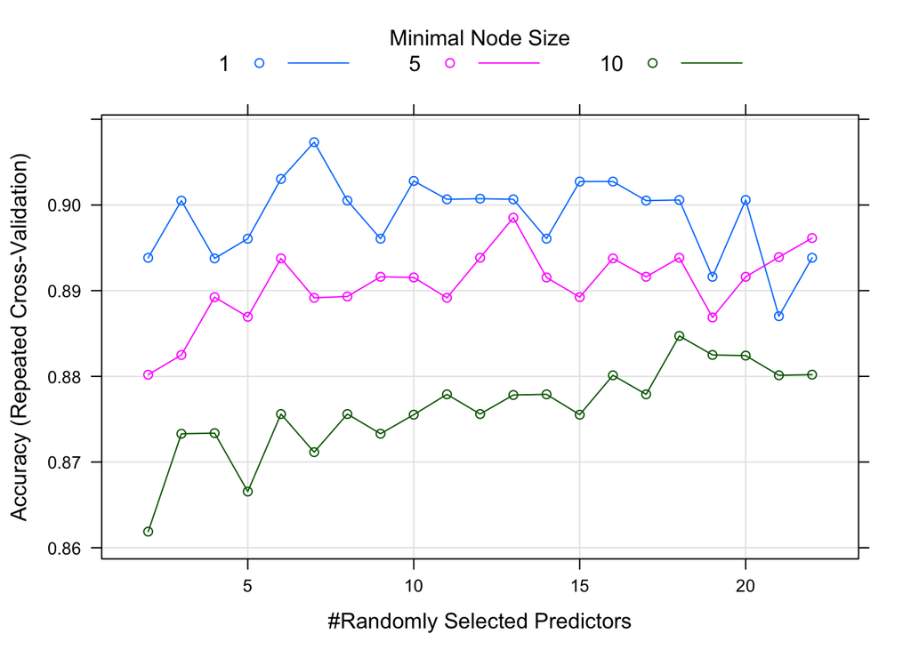

```r
plot(train.by.grid)
```

It appears that a minimal node size of 1 generally has the highest value of accuracy for values of mtry between 7 and 15.

```r
pred = predict(object=train.by.grid,newdata=test.set)
table(pred)
```

```
## pred
## Zero  One
##    8   40
```

```r
conf.matrix = confusionMatrix(data=pred,reference=test.set[,'status'])
conf.matrix
```

```
## Confusion Matrix and Statistics
##
##           Reference
## Prediction Zero One
##       Zero    8   0
##       One     4  36
##
##                Accuracy : 0.9167
##                  95% CI : (0.8002, 0.9768)
##     No Information Rate : 0.75
##     P-Value [Acc > NIR] : 0.003207
##
##                   Kappa : 0.75
##  Mcnemar's Test P-Value : 0.133614
##
##             Sensitivity : 0.6667
##             Specificity : 1.0000
##          Pos Pred Value : 1.0000
##          Neg Pred Value : 0.9000
##              Prevalence : 0.2500
##          Detection Rate : 0.1667
##    Detection Prevalence : 0.1667
##       Balanced Accuracy : 0.8333
##
##        'Positive' Class : Zero
##
```

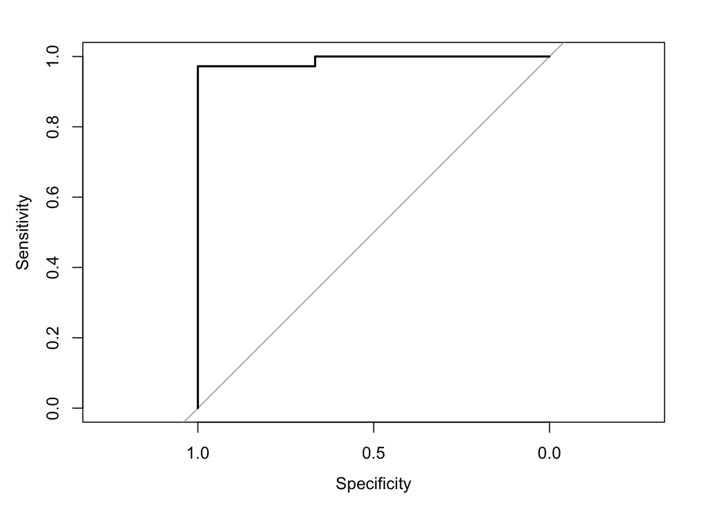

```r
pred = predict(object=train.by.grid,newdata=test.set,type="prob")
roc.curve = roc(test.set$status=="One",pred$One)
plot(roc.curve)
```

Fine-tune the values of the hyperparameters by focusing on their identified optimal ranges.

```r
tuneGrid = expand.grid(mtry = seq(7,15,0.5),
                       splitrule = c("extratrees"),
                       min.node.size = c(1,2,5))

tuneGrid
```

| mtry | splitrule | min.node.size |
| --- | --- | --- |
| 7.0 | extratrees | 1 |
| 7.5 | extratrees | 1 |
| 8.0 | extratrees | 1 |
| 8.5 | extratrees | 1 |
| 9.0 | extratrees | 1 |
| 9.5 | extratrees | 1 |
| 10.0 | extratrees | 1 |
| 10.5 | extratrees | 1 |
| 11.0 | extratrees | 1 |
| 11.5 | extratrees | 1 |

[output cut: 41 more lines]

```r
train.by.grid = train(form=status~.,data=training.set,method='ranger',
                      metric="Accuracy",tuneGrid=tuneGrid,
                      trControl=trControl)
train.by.grid['results']
```

```
## $results
##    mtry  splitrule min.node.size  Accuracy     Kappa AccuracySD   KappaSD
## 1   7.0 extratrees             1 0.9046743 0.7044224 0.04895809 0.1683964
## 2   7.0 extratrees             2 0.9024521 0.6987410 0.04478729 0.1560300
## 3   7.0 extratrees             5 0.8933333 0.6572631 0.05514025 0.2258322
## 4   7.5 extratrees             1 0.8954789 0.6769269 0.04227159 0.1523368
## 5   7.5 extratrees             2 0.9114943 0.7209502 0.05333737 0.1829719
## 6   7.5 extratrees             5 0.8978544 0.6713735 0.05683700 0.2291623
## 7   8.0 extratrees             1 0.9023755 0.6991039 0.04479487 0.1491070
## 8   8.0 extratrees             2 0.9046743 0.7076699 0.04344303 0.1485907
## 9   8.0 extratrees             5 0.8979310 0.6825113 0.04690605 0.1626341
## 10  8.5 extratrees             1 0.9047510 0.7090460 0.04142915 0.1372901
## 11  8.5 extratrees             2 0.9046743 0.6994021 0.05391189 0.1972147
## 12  8.5 extratrees             5 0.8887356 0.6458694 0.05133442 0.2165957
## 13  9.0 extratrees             1 0.9116475 0.7318926 0.04437238 0.1419474
```

[output cut: 38 more lines]

Print the best hyperparameter combination:

```r
train.by.grid['bestTune']
```

```
## $bestTune
##    mtry  splitrule min.node.size
## 37   13 extratrees             1
```

Graphically compare the best hyperparameter combination with the other investigated possibilities.

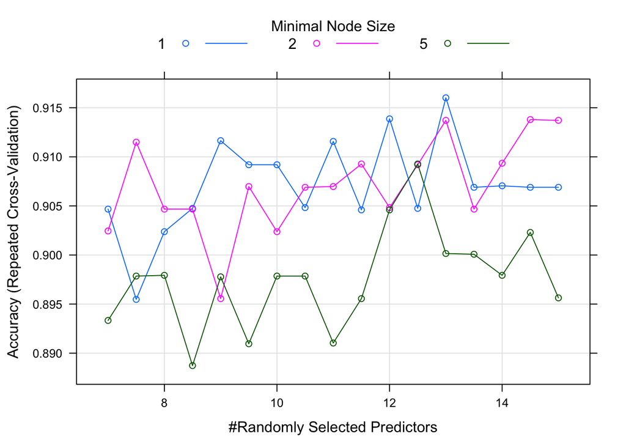

```r
plot(train.by.grid)
```

```r
pred = predict(object=train.by.grid,newdata=test.set)
table(pred)
```

```
## pred
## Zero  One
##    9   39
```

```r
conf.matrix = confusionMatrix(data=pred,reference=test.set[,'status'])
conf.matrix
```

```
## Confusion Matrix and Statistics
##
##           Reference
## Prediction Zero One
##       Zero    8   1
##       One     4  35
##
##                Accuracy : 0.8958
##                  95% CI : (0.7734, 0.9653)
##     No Information Rate : 0.75
##     P-Value [Acc > NIR] : 0.0103
##
##                   Kappa : 0.697
##  Mcnemar's Test P-Value : 0.3711
##
##             Sensitivity : 0.6667
##             Specificity : 0.9722
##          Pos Pred Value : 0.8889
##          Neg Pred Value : 0.8974
##              Prevalence : 0.2500
##          Detection Rate : 0.1667
##    Detection Prevalence : 0.1875
##       Balanced Accuracy : 0.8194
##
##        'Positive' Class : Zero
##
```

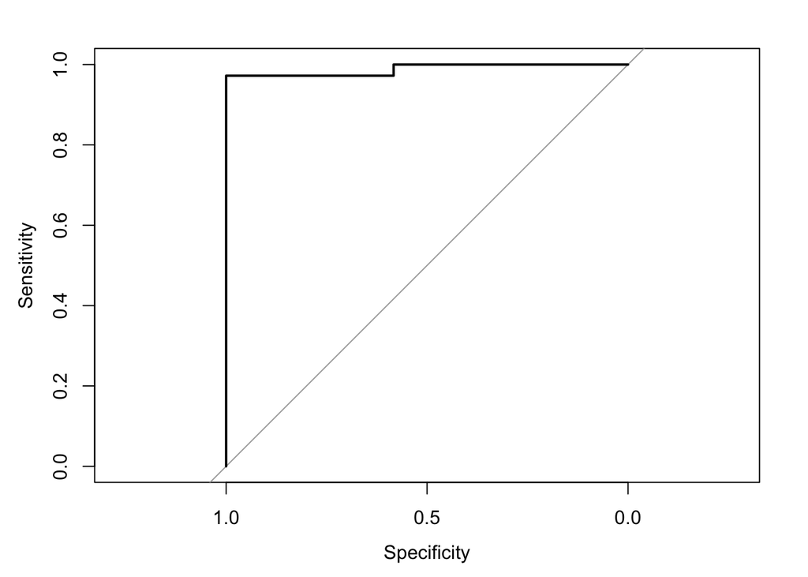

```r
pred = predict(object=train.by.grid,newdata=test.set,type="prob")
roc.curve = roc(test.set$status=="One",pred$One)
plot(roc.curve)
```

```r
auc(roc.curve)
```

```
## Area under the curve: 0.9884
```

The best binary classification model is therefore random forest with a combination of “mtry,” “splitrule,” and “min.node.size” that can be tuned even further for optimal performance.